# Introduction and R Basics

Statistical Computing, 36-350

Monday July 2, 2018

# Why statisticians learn to program

- **Independence**: otherwise, you rely on someone else giving you exactly the right tool
- **Honesty**: otherwise, you end up distorting your problem to match the tools you have
- **Clarity**: often, turning your ideas into something a machine can do refines your thinking
- **Fun**: these were the best of times (the worst of times)

# Cool example: percolation

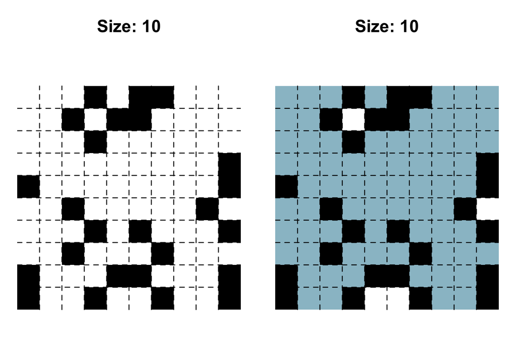

# How this class will work

# R, R Studio, R Markdown

- R is a programming language for statistical computing
- R Studio is an integrated development environment for R programming
- R Markdown is a markup language for combining R code with text

All 3 are free, and all 3 will be used extensively in this course

# Read the syllabus

It’s on the course website, please read it (actually read it)

# Late days

- Each student is given 5 late days for the semester, for both homeworks and labs
- Late days are automatically used (you do not need to email the TA beforehand)
- Each late day is counted as up to 24 hours after the assignment is due
- Assignments submitted after all 5 late days are used receive a 0
- Email the TA for extreme circumstances (read the syllabus)

# Communicating with the instructor/TA

- Email the TA for any questions about the course (mainly, asking for extension, excusing absence in class, asking for regrade). Put “[36-350]” in the subject of the email
- You should not need to email the instructor for anything (unless the instructor asks you to)
- Questions about assignment content should be on Piazza
- Read syllabus for Piazza guidelines. It is **not** a question-answer hotline. Piazza is meant to be a collaborative forum for students to help each other out, guided by the instructor/TA.

# Laptop

- You will be needing a laptop for each class for lab
- If you do not have a laptop, please let the instructor/TA know. We will be able to make arrangements to lend you a laptop for the session
- For courtesy of other students and understanding, **you may not be using your laptop while the instructor is lecturing**

# Copying/cheating

- Don’t do it, refer to syllabus if you’re unclear about anything  
  (and if you’re still unclear, come see me)
- If you are struggling with the material, let me or Matteo know immediately. (The summer session goes by fast!)

# What should you call me?

Please don’t call me “Professor”. Call me Kevin.

# Things to do

- Install R Studio on your laptop
- Get comfortable with R Studio, knitting Rmd documents into HTML files
- Get comfortable with basics of the R language!
- Complete and submit lab by Monday 10pm *(note different time)*

# Percolation

(demo)

# Part I

*Data types, operators, variables*

# This class in a nutshell: functional programming

Two basic types of things/objects: **data** and **functions**

- **Data**: things like 7, “seven”, $7.000$, and $\left[ \begin{array}{ccc} 7 & 7 & 7 \\ 7 & 7 & 7\end{array}\right]$
- **Functions**: things like `log`, `+` (takes two arguments), `<` (two), `%%` (two), and `mean` (one)

> A function is a machine which turns input objects, or **arguments**, into an output object, or a **return value** (possibly with side effects), according to a definite rule
- Programming is writing functions to transform inputs into outputs
- Good programming ensures the transformation is done easily and correctly
- Machines are made out of machines; functions are made out of functions, like $f(a,b) = a^2 + b^2$

> The trick to good programming is to take a big transformation and **break it down** into smaller ones, and then break those down, until you come to tasks which are easy (using built-in functions)

# Before functions, data

At base level, all data can represented in binary format, by **bits** (i.e., TRUE/FALSE, YES/NO, 1/0). Basic data types:

- **Booleans**: Direct binary values: `TRUE` or `FALSE` in R
- **Integers**: whole numbers (positive, negative or zero), represented by a fixed-length block of bits
- **Characters**: fixed-length blocks of bits, with special coding; **strings**: sequences of characters
- **Floating point numbers**: an integer times a positive integer to the power of an integer, as in $3 \times 10^6$ or $1 \times 3^{-1}$
- **Missing or ill-defined values**: `NA`, `NaN`, etc.

# Operators

- **Unary**: take just one argument. E.g., `-` for arithmetic negation, `!` for Boolean negation
- **Binary**: take two arguments. E.g., `+`, `-`, `*`, and `/` (though this is only a partial operator). Also, `%%` (for mod), and `^` (again partial)

```r
-7
```

```
## [1] -7
```

```r
7 + 5
```

```
## [1] 12
```

```r
7 - 5
```

```
## [1] 2
```

```r
7 * 5
```

```
## [1] 35
```

```r
7 ^ 5
```

```
## [1] 16807
```

```r
7 / 5
```

```
## [1] 1.4
```

```r
7 %% 5
```

```
## [1] 2
```

# R console

- Basic interaction with R is by typing in the **console**, i.e., **terminal**, or **command line**
- You type in commands, R gives back answers (or errors)
- Menus and other graphical interfaces are extras built on top of the console

# Comparison operators

These are also binary operators; they take two objects, and give back a Boolean

```r
7 > 5
```

```
## [1] TRUE
```

```r
7 < 5
```

```
## [1] FALSE
```

```r
7 >= 7
```

```
## [1] TRUE
```

```r
7 <= 5
```

```
## [1] FALSE
```

```r
7 == 5
```

```
## [1] FALSE
```

```r
7 != 5
```

```
## [1] TRUE
```

Warning: `==` is a comparison operator, `=` is not!

# Logical operators

These basic ones are `&` (and) and `|` (or)

```r
(5 > 7) & (6 * 7 == 42)
```

```
## [1] FALSE
```

```r
(5 > 7) | (6 * 7 == 42)
```

```
## [1] TRUE
```

```r
(5 > 7) | (6 * 7 == 42) & (0 != 0)
```

```
## [1] FALSE
```

```r
(5 > 7) | (6 * 7 == 42) & (0 != 0) | (9 - 8 >= 0)
```

```
## [1] TRUE
```

Note: The double forms `&&` and `||` are different! We’ll see them later

# More types

- The `typeof()` function returns the data type
- `is.foo()` functions return Booleans for whether the argument is of type *foo*
- `as.foo()` (tries to) “cast” its argument to type *foo*, to translate it sensibly into such a value

```r
typeof(7)
```

```
## [1] "double"
```

```r
is.numeric(7)
```

```
## [1] TRUE
```

```r
is.na(7)
```

```
## [1] FALSE
```

```r
is.na(7/0)
```

```
## [1] FALSE
```

```r
is.na(0/0)
```

```
## [1] TRUE
```

```r
is.character(7)
```

```
## [1] FALSE
```

```r
is.character("7")
```

```
## [1] TRUE
```

```r
is.character("seven")
```

```
## [1] TRUE
```

```r
is.na("seven")
```

```
## [1] FALSE
```

```r
as.character(5/6)
```

```
## [1] "0.833333333333333"
```

```r
as.numeric(as.character(5/6))
```

```
## [1] 0.8333333
```

```r
6 * as.numeric(as.character(5/6))
```

```
## [1] 5
```

```r
5/6 == as.numeric(as.character(5/6))
```

```
## [1] FALSE
```

# Data can have names

We can give names to data objects; these give us **variables**. Some variables are built-in:

```r
pi
```

```
## [1] 3.141593
```

Variables can be arguments to functions or operators, just like constants:

```r
pi * 10
```

```
## [1] 31.41593
```

```r
cos(pi)
```

```
## [1] -1
```

We create variables with the **assignment operator**, `<-` or `=`

```r
approx.pi = 22/7
approx.pi
```

```
## [1] 3.142857
```

```r
diameter = 10
approx.pi * diameter
```

```
## [1] 31.42857
```

The assignment operator also changes values:

```r
circumference = approx.pi * diameter
circumference
```

```
## [1] 31.42857
```

```r
circumference = 30
circumference
```

```
## [1] 30
```

- The code you write will be made of variables, with descriptive names
- Easier to design, easier to debug, easier to improve, and easier for others to read
- Avoid “magic constants”; instead use named variables
- Named variables are a first step towards **abstraction**

# R workspace

What variables have you defined?

```r
ls()
```

```
## [1] "approx.pi"     "circumference" "diameter"
```

Getting rid of variables:

```r
rm("circumference")
ls()
```

```
## [1] "approx.pi" "diameter"
```

```r
rm(list=ls()) # Be warned! This erases everything
ls()
```

```
## character(0)
```

# Part II

*Data structures*

# First data structure: vectors

- A **data structure** is a grouping of related data values into an object
- A **vector** is a sequence of values, all of the same type

```r
x = c(7, 8, 10, 45)
x
```

```
## [1]  7  8 10 45
```

```r
is.vector(x)
```

```
## [1] TRUE
```

- The `c()` function returns a vector containing all its arguments in specified order
- `1:5` is shorthand for `c(1,2,3,4,5)`, and so on
- `x[1]` would be the first element, `x[4]` the fourth element, and `x[-4]` is a vector containing *all but* the fourth element

`vector(length=n)` returns an empty vector of length *n*; helpful for filling things up later

```r
weekly.hours = vector(length=5)
weekly.hours
```

```
## [1] FALSE FALSE FALSE FALSE FALSE
```

```r
weekly.hours[5] = 8
weekly.hours
```

```
## [1] 0 0 0 0 8
```

# Vector arithmetic

Arithmetic operator apply to vectors in a “componentwise” fashion

```r
y = c(-7, -8, -10, -45)
x + y
```

```
## [1] 0 0 0 0
```

```r
x * y
```

```
## [1]   -49   -64  -100 -2025
```

# Recycling

**Recycling** repeat elements in shorter vector when combined with a longer one

```r
x + c(-7,-8)
```

```
## [1]  0  0  3 37
```

```r
x^c(1,0,-1,0.5)
```

```
## [1] 7.000000 1.000000 0.100000 6.708204
```

Single numbers are vectors of length 1 for purposes of recycling:

```r
2 * x
```

```
## [1] 14 16 20 90
```

Can do componentwise comparisons with vectors:

```r
x > 9
```

```
## [1] FALSE FALSE  TRUE  TRUE
```

Logical operators also work elementwise:

```r
(x > 9) & (x < 20)
```

```
## [1] FALSE FALSE  TRUE FALSE
```

To compare whole vectors, best to use `identical()` or `all.equal()`:

```r
x == -y
```

```
## [1] TRUE TRUE TRUE TRUE
```

```r
identical(x, -y)
```

```
## [1] TRUE
```

```r
identical(c(0.5-0.3,0.3-0.1), c(0.3-0.1,0.5-0.3))
```

```
## [1] FALSE
```

```r
all.equal(c(0.5-0.3,0.3-0.1), c(0.3-0.1,0.5-0.3))
```

```
## [1] TRUE
```

Note: these functions are slightly different; we’ll see more later

# Functions on vectors

Many functions can take vectors as arguments:

- `mean()`, `median()`, `sd()`, `var()`, `max()`, `min()`, `length()`, and `sum()` return single numbers
- `sort()` returns a new vector
- `hist()` takes a vector of numbers and produces a histogram, a highly structured object, with the side effect of making a plot
- `ecdf()` similarly produces a cumulative-density-function object
- `summary()` gives a five-number summary of numerical vectors
- `any()` and `all()` are useful on Boolean vectors

# Indexing vectors

Vector of indices:

```r
x[c(2,4)]
```

```
## [1]  8 45
```

Vector of negative indices:

```r
x[c(-1,-3)]
```

```
## [1]  8 45
```

Boolean vector:

```r
x[x > 9]
```

```
## [1] 10 45
```

```r
y[x > 9]
```

```
## [1] -10 -45
```

`which()` gives the elements of a Boolean vector that are `TRUE`:

```r
places = which(x > 9)
places
```

```
## [1] 3 4
```

```r
y[places]
```

```
## [1] -10 -45
```

# Named components

We can give names to elements/components of vectors, and index vectors accordingly

```r
names(x) = c("v1","v2","v3","fred")
names(x)
```

```
## [1] "v1"   "v2"   "v3"   "fred"
```

```r
x[c("fred","v1")]
```

```
## fred   v1
##   45    7
```

Note: here R is printing the labels, these are not additional components of `x`

`names()` returns another vector (of characters):

```r
names(y) = names(x)
sort(names(x))
```

```
## [1] "fred" "v1"   "v2"   "v3"
```

```r
which(names(x) == "fred")
```

```
## [1] 4
```

# Second data structure: matrices

A **matrix** is a specialization of a 2d array

```r
z.mat = matrix(c(40,1,60,3), nrow=2)
z.mat
```

```
##      [,1] [,2]
## [1,]   40   60
## [2,]    1    3
```

```r
dim(z.mat)
```

```
## [1] 2 2
```

```r
is.array(z.mat)
```

```
## [1] TRUE
```

```r
is.matrix(z.mat)
```

```
## [1] TRUE
```

- `dim` says how many rows and columns; filled by columns by default
- Could also specify `ncol` for the number of columns
- To fill by rows, use `byrow=TRUE`
- Elementwise operations with the usual arithmetic and comparison operators (e.g., `z.mat/3`)

# Indexing matrices

Can access a matrices either by pairs of indices or by the underlying vector (column-major order):

```r
z.mat[1,2]
```

```
## [1] 60
```

```r
z.mat[3]
```

```
## [1] 60
```

Omitting an index means “all of it”:

```r
z.mat[c(1,2),2]
```

```
## [1] 60  3
```

```r
z.mat[,2]
```

```
## [1] 60  3
```

```r
z.mat[,2,drop=FALSE]
```

```
##      [,1]
## [1,]   60
## [2,]    3
```

# Functions on matrices

Many functions applied to an array will just boil things down to the underlying vector:

```r
which(z.mat > 9)
```

```
## [1] 1 3
```

This happens unless the function is set up to handle arrays specifically

And there are several functions/operators that *do* preserve array structure:

```r
y.mat = matrix(1:4, nrow=2)
y.mat + z.mat
```

```
##      [,1] [,2]
## [1,]   41   63
## [2,]    3    7
```

Others specifically act on each row or column of the array separately:

```r
rowSums(z.mat)
```

```
## [1] 100   4
```

```r
colSums(z.mat)
```

```
## [1] 41 63
```

# Matrix multiplication

Has its own special operator, written `%*%`:

```r
six.sevens = matrix(rep(7,6), ncol=3)
six.sevens
```

```
##      [,1] [,2] [,3]
## [1,]    7    7    7
## [2,]    7    7    7
```

```r
z.mat %*% six.sevens # [2x2] * [2x3]
```

```
##      [,1] [,2] [,3]
## [1,]  700  700  700
## [2,]   28   28   28
```

# Multiplying matrices and vectors

Numeric vectors can act like column or row vectors, as needed:

```r
a.vec = c(10,20)
z.mat %*% a.vec
```

```
##      [,1]
## [1,] 1600
## [2,]   70
```

```r
a.vec %*% z.mat
```

```
##      [,1] [,2]
## [1,]  420  660
```

# Matrix operators

Transpose:

```r
t(z.mat)
```

```
##      [,1] [,2]
## [1,]   40    1
## [2,]   60    3
```

Determinant:

```r
det(z.mat)
```

```
## [1] 60
```

# Names in matrices

- We can name either rows or columns or both, with `rownames()` and `colnames()`
- These are just character vectors, and we use them just like we do `names()` for vectors
- Names help us understand what we’re working with

# Third data structure: lists

A **list** is sequence of values, but not necessarily all of the same type

```r
my.dist = list("exponential", 7, FALSE)
my.dist
```

```
## [[1]]
## [1] "exponential"
##
## [[2]]
## [1] 7
##
## [[3]]
## [1] FALSE
```

Most of what you can do with vectors you can also do with lists

# Accessing pieces of lists

- Can use `[ ]` as with vectors
- Or use `[[ ]]`, but only with a single index `[[ ]]` drops names and structures, `[ ]` does not

```r
my.dist[2]
```

```
## [[1]]
## [1] 7
```

```r
my.dist[[2]]
```

```
## [1] 7
```

```r
my.dist[[2]]^2
```

```
## [1] 49
```

# Expanding and contracting lists

Add to lists with `c()` (also works with vectors):

```r
my.dist = c(my.dist, 9)
my.dist
```

```
## [[1]]
## [1] "exponential"
##
## [[2]]
## [1] 7
##
## [[3]]
## [1] FALSE
##
## [[4]]
## [1] 9
```

Chop off the end of a list by setting the length to something smaller (also works with vectors):

```r
length(my.dist)
```

```
## [1] 4
```

```r
length(my.dist) = 3
my.dist
```

```
## [[1]]
## [1] "exponential"
##
## [[2]]
## [1] 7
##
## [[3]]
## [1] FALSE
```

Pluck out all but one piece of a list (also works with vectors):

```r
my.dist[-2]
```

```
## [[1]]
## [1] "exponential"
##
## [[2]]
## [1] FALSE
```

# Names in lists

We can name some or all of the elements of a list:

```r
names(my.dist) = c("family","mean","is.symmetric")
my.dist
```

```
## $family
## [1] "exponential"
##
## $mean
## [1] 7
##
## $is.symmetric
## [1] FALSE
```

```r
my.dist[["family"]]
```

```
## [1] "exponential"
```

```r
my.dist["family"]
```

```
## $family
## [1] "exponential"
```

Lists have a special shortcut way of using names, with `$`:

```r
my.dist[["family"]]
```

```
## [1] "exponential"
```

```r
my.dist$family
```

```
## [1] "exponential"
```

Creating a list with names:

```r
another.dist = list(family="gaussian",
                            mean=7, sd=1, is.symmetric=TRUE)
```

Adding named elements:

```r
my.dist$was.estimated = FALSE
my.dist[["last.updated"]] = "2015-09-01"
```

Removing a named list element, by assigning it the value `NULL`:

```r
my.dist$was.estimated = NULL
```

# Key-value pairs

- Lists give us a natural way to store and look up data by *name*, rather than by *position*
- A really useful programming concept with many names: **key-value pairs**, i.e., **dictionaries**, or **associative arrays**
- If all our distributions have components named `family`, we can look that up by name, without caring where it is (in what position it lies) in the list

# Data frames

- The classic data table, $n$ rows for cases, $p$ columns for variables
- Lots of the really-statistical parts of R presume data frames
- Not just a matrix because *columns can have different types*
- Many matrix functions also work for data frames (e.g.,`rowSums()`, `summary()`, `apply()`)

```r
a.mat = matrix(c(35,8,10,4), nrow=2)
colnames(a.mat) = c("v1","v2")
a.mat
```

```
##      v1 v2
## [1,] 35 10
## [2,]  8  4
```

```r
a.mat[,"v1"]  # Try a.mat$v1 and see what happens
```

```
## [1] 35  8
```

```r
a.df = data.frame(a.mat,logicals=c(TRUE,FALSE))
a.df
```

```
##   v1 v2 logicals
## 1 35 10     TRUE
## 2  8  4    FALSE
```

```r
a.df$v1
```

```
## [1] 35  8
```

```r
a.df[,"v1"]
```

```
## [1] 35  8
```

```r
a.df[1,]
```

```
##   v1 v2 logicals
## 1 35 10     TRUE
```

```r
colMeans(a.df)
```

```
##       v1       v2 logicals
##     21.5      7.0      0.5
```

# Adding rows and columns

We can add rows or columns to an array or data frame with `rbind()` and `cbind()`, but be careful about forced type conversions

```r
rbind(a.df,list(v1=-3,v2=-5,logicals=TRUE))
```

```
##   v1 v2 logicals
## 1 35 10     TRUE
## 2  8  4    FALSE
## 3 -3 -5     TRUE
```

```r
rbind(a.df,c(3,4,6))
```

```
##   v1 v2 logicals
## 1 35 10        1
## 2  8  4        0
## 3  3  4        6
```

Much more on data frames a bit later in the course …

# Structures of structures

So far, every list element has been a single data value. List elements can be other data structures, e.g., vectors and matrices, even other lists:

```r
my.list = list(z.mat=z.mat, my.lucky.num=13, my.dist=my.dist)
my.list
```

```
## $z.mat
##      [,1] [,2]
## [1,]   40   60
## [2,]    1    3
##
## $my.lucky.num
## [1] 13
##
## $my.dist
## $my.dist$family
## [1] "exponential"
##
## $my.dist$mean
## [1] 7
##
## $my.dist$is.symmetric
## [1] FALSE
##
## $my.dist$last.updated
## [1] "2015-09-01"
```

# Summary

- We write programs by composing functions to manipulate data
- The basic data types let us represent Booleans, numbers, and characters
- Data structures let us group together related values
- Vectors let us group values of the same type
- Arrays add multi-dimensional structure to vectors
- Matrices act like you’d hope they would
- Lists let us combine different types of data
- Data frames are hybrids of matrices and lists, allowing each column to have a different data type